# Aderência deputado - partido

16/12/2019

### **Resumo**

*Analisamos quais deputados federais mais/menos seguem as orientações de seus partidos nas votações nominais em plenário da Câmara. Usamos as votações que aconteceram em 2019.*

## O que é aderência

Aderência é uma faceda da atuação dos Deputados Federais na câmara em votações. Um deputado é aderente quando segue as orientações de seu partido em votações nominais.

Examinamos aderência com os dados de **votações nominais realizadas em plenário** para o ano de **2019**. Assim, todos os deputados analisados aqui participaram da legislatura atual da Câmara dos Deputados (legislatura 56).

Partimos de 82 proposições que, segundo a API da Câmara dos Deputados, tiveram votações realizadas em plenário no ano de 2019. A lista completa está disponível [aqui](https://www.camara.leg.br/SitCamaraWS/Proposicoes.asmx/ListarProposicoesVotadasEmPlenario?ano=2019&tipo=).

Essas proposições tiveram 314 votações em plenário. Capturamos os resultados de todas essas votações observando principalmente: o **voto do deputado** e a **orientação do partido**.

Para cada votação de cada deputado, identificamos se ele seguiu a orientação do partido ou não. Em seguida, calculamos o grau de aderência como *a proporção das votações em que ele seguiu a orientação do partido*. Quando o partido liberou o deputado em uma votação, essa votação não é considerada.

Como os deputados não estão sempre presentes e os partidos nem sempre orientam as votações, a quantidade de votações considerada varia entre os deputados. Nesta análise, *consideramos apenas deputados que participaram em pelo menos 10 votações que o partido orientou, e apenas deputados de partidos com ao menos 5 membros na câmara*.

## Quem tem menos aderência?

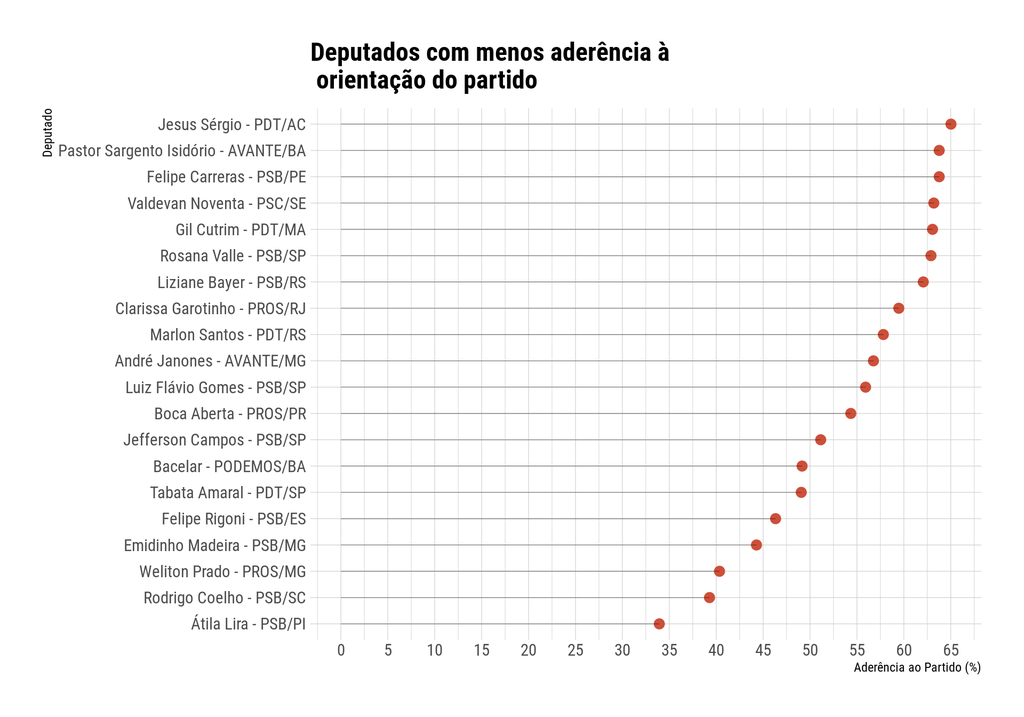

Acima temos a informações dos 20 deputados que possuem **menor aderência** com seu partido. Átila Lira (PSB/PI) é o deputado com menor aderência da Câmara. Ele seguiu o partido em 75 votações e não seguiu em 146 votações. A aderência para Átila é de 75 / (75 + 146), isto é 34%.

Abaixo detalhamos o número absoluto de votações em que cada um desses deputados seguiu ou não a orientação do partido. As barras têm comprimento diferente pois os deputados tem um número diferente de votações nas quais participaram e houve orientação do partido. Os deputaods estão ordenados da maior aderência para a menor.

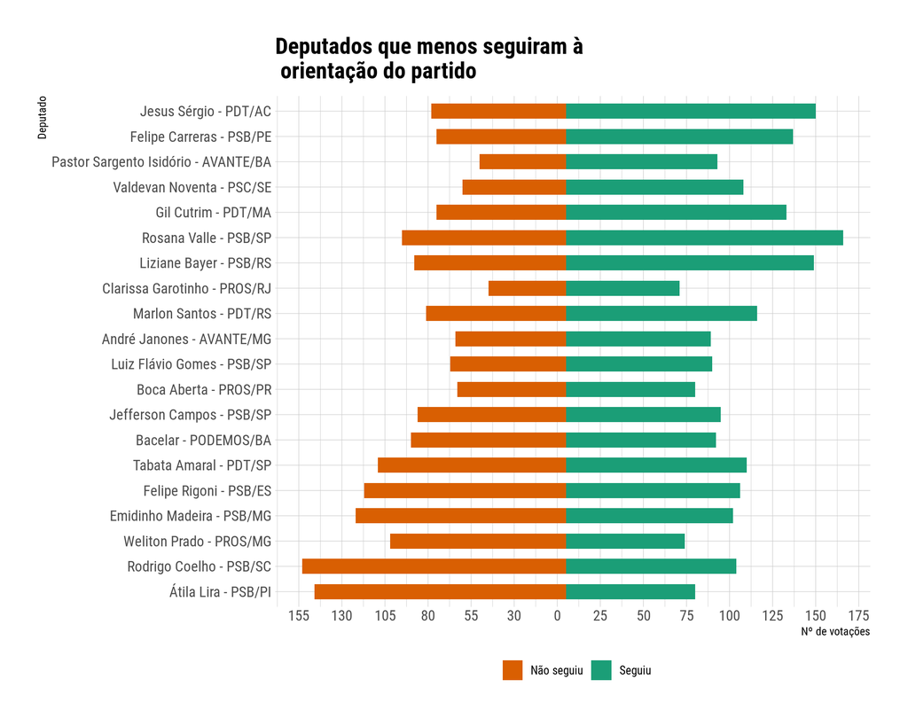

### Quem são os deputados de maior aderência?

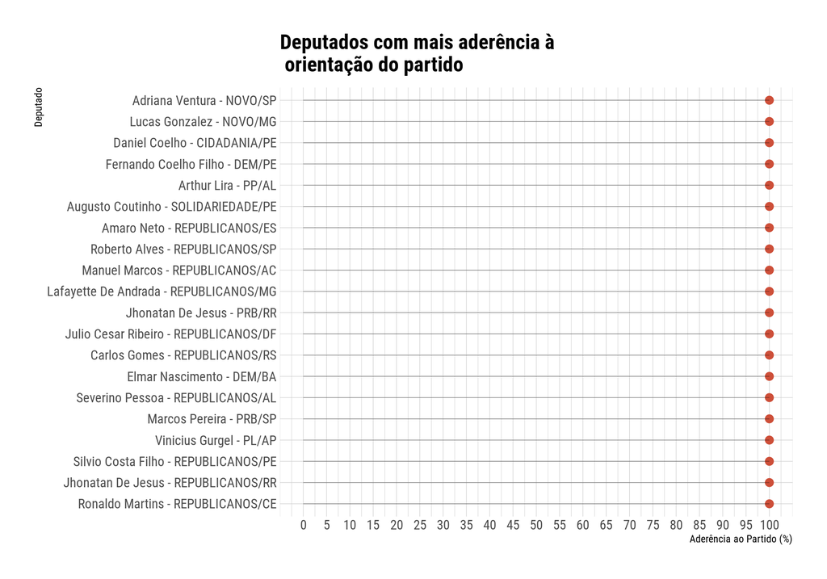

Na lista dos 20 deputados com maior valor de aderência todos têm aderência de 100%; ou seja, seguiram todas as orientações propostas pelo seu partido. Abaixo detalhamos em quantas votações cada um esteve.

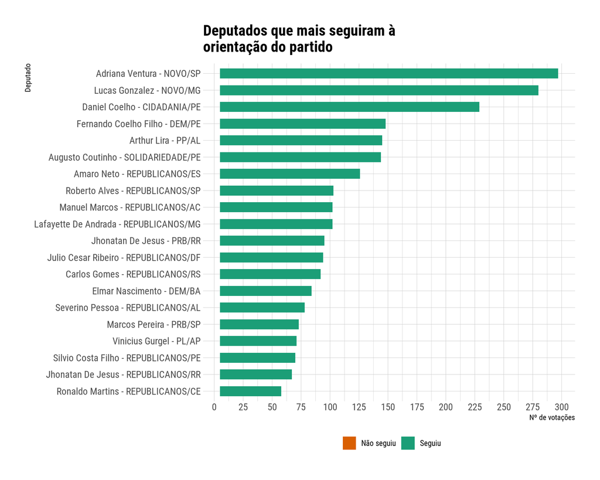

### Mais detalhes sobre quem não adere

Se olharmos com mais detalhes para a lista de 20 deputados que menos adere, podemos destrinchar como ocorreram as votações para cada deputado. Átila Lira, mostrado na visualização anterior com menos de 34% de aderência, teve 75 votações em que seguiu o partido, 146 em que não seguiu o partido, 22 em que o partido liberou o voto e outras 28 em que faltou.

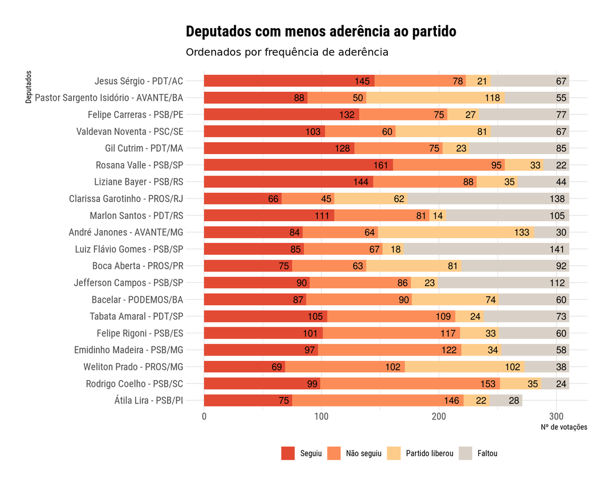

## Aderência por partido

Subindo o nível de visão, podemos analisar a aderência dos deputados por partido.

O gráfico abaixo ajuda a entender melhor a distribuição dos pontos (deputados) ao longo do eixo de aderência.Os partidos estão ordenados pela mediana, portanto, o partido NOVO é considerando o partido com deputados mais aderentes, seguido pelo REPUBLICANOS. As maiores amplitudes (diferença entre o máximo e o mínimo) são observadas para o PSB e PROS. Existem deputados que nesses partidos que são muito aderentes e outros que são pouco aderentes.

As cores na visualização apenas ajudam a diferenciar deputados vizinhos um ao outro (na própria visualização).

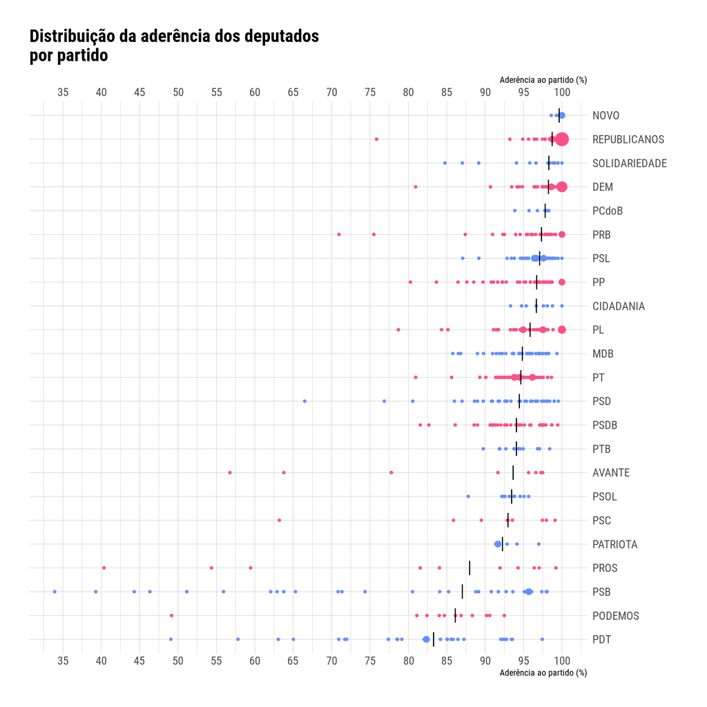

Interessante observar que o PT não apresenta uma alta mediana de aderência quando comparado a outros partidos que ganharam mais vagas no parlamento na última eleição, como o PSL.

## Aderência por votação

Quando olhamos a aderência para cada votação do conjunto das 314 abordadas podemos analisar a proporção do nº de deputados que seguiu a orientação do partido sobre o nº de deputados que seguiu somado com o nº de deputados que não seguiu.

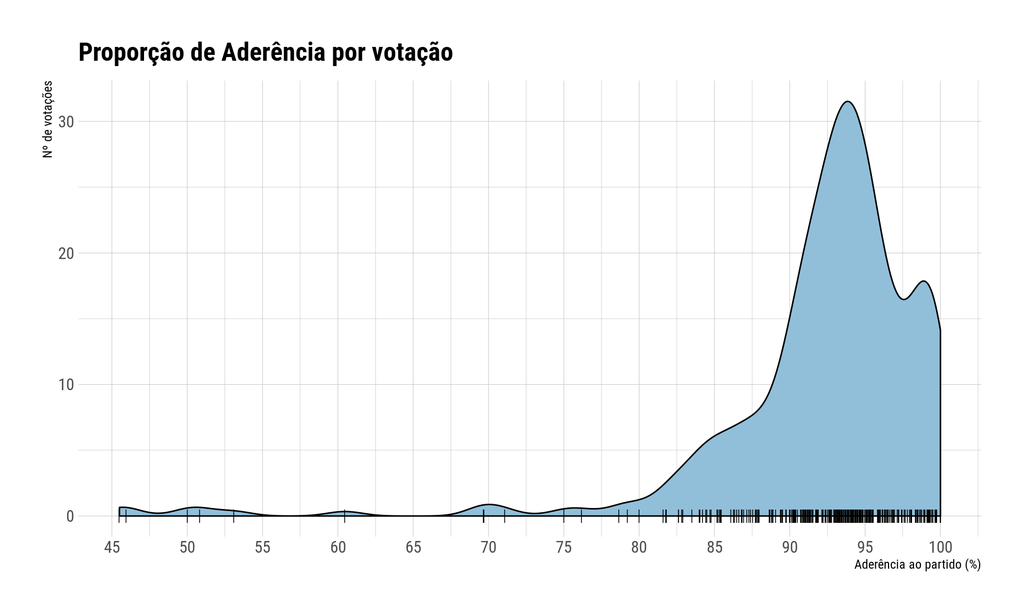

Como mostrado, a aderência por votação em geral é bem alta já que a densidade de votações com alta aderência aos partidos se concentra acima do valor de 80%. Foram excluídos do cálculo deputados com menos de 10 votações com orientação e partidos com menos de 5 membros. Ou seja, geralmente os deputados seguem a orientação do partido. Cada marca “|” no gráfico representa uma votação ocorrida em 2019. A posição dessa marca no eixo x representa o quanto de aderência aos partidos os deputados tiveram.

As três votações com menos aderência são:

- REQUERIMENTO DE RETIRADA DE PAUTA da [PDC 379/2016](https://www.camara.leg.br/proposicoesWeb/fichadetramitacao?idProposicao=2083376). Aprova o texto do Acordo de Cooperação Educacional entre o Governo da República Federativa do Brasil e o Governo da Federação de São Cristóvão e Névis, assinado em Brasília, em 26 de abril de 2010.
- REQUERIMENTO DE ADIAMENTO DA VOTAÇÃO POR 2 SESSÕES da [PL 1292/1995](https://www.camara.leg.br/proposicoesWeb/fichadetramitacao?idProposicao=16526). Altera a lei nº 8.666, de 21 de junho de 1993, que regulamenta o art. 37, inciso XXI, da Constituição Federal, institui normas para licitações e contratos da Administração Pública e dá outras providências.
- CRÉDITO SUPLEMENTAR - PODER JUDICIÁRIO E MINISTÉRIO PÚBLICO [PLN 6/2019 CN](https://www.camara.leg.br/proposicoesWeb/fichadetramitacao?idProposicao=2202987). Abre ao Orçamento Fiscal da União, em favor das Justiças Federal, Eleitoral, do Trabalho e do Distrito Federal e dos Territórios, do Ministério Público da União e do Conselho Nacional do Ministério Público, crédito suplementar no valor de R$ 236.566.628,00, para reforço de dotações constantes da Lei Orçamentária vigente.
- A [votação](https://www.camara.leg.br/internet/votacao/mostraVotacao.asp?ideVotacao=8846&numLegislatura=56&codCasa=1&numSessaoLegislativa=1&indTipoSessaoLegislativa=O&numSessao=114&indTipoSessao=E&tipo=uf) da permanência do COAF no Ministério da Justiça teve 80% de aderência.

Abaixo apresentamos uma tabela pesquisável com os dados de todos os deputados que participaram de votações no ano de 2019.

| id | Nome | Partido | Aderência | Seguiu | Não Seguiu | Faltou | Partido liberou |
| --- | --- | --- | --- | --- | --- | --- | --- |
| 74459 | Átila Lira - PSB/PI | PSB | 33.94 | 75 | 146 | 28 | 22 |
| 204366 | Rodrigo Coelho - PSB/SC | PSB | 39.29 | 99 | 153 | 24 | 35 |
| 160518 | Weliton Prado - PROS/MG | PROS | 40.35 | 69 | 102 | 38 | 102 |
| 161550 | Emidinho Madeira - PSB/MG | PSB | 44.29 | 97 | 122 | 58 | 34 |
| 204371 | Felipe Rigoni - PSB/ES | PSB | 46.33 | 101 | 117 | 60 | 33 |
| 204534 | Tabata Amaral - PDT/SP | PDT | 49.07 | 105 | 109 | 73 | 24 |
| 69871 | Bacelar - PODEMOS/BA | PODEMOS | 49.15 | 87 | 90 | 60 | 74 |
| 74273 | Jefferson Campos - PSB/SP | PSB | 51.14 | 90 | 86 | 112 | 23 |
| 204397 | Boca Aberta - PROS/PR | PROS | 54.35 | 75 | 63 | 92 | 81 |
| 204543 | Luiz Flávio Gomes - PSB/SP | PSB | 55.92 | 85 | 67 | 141 | 18 |

[output cut: 545 more lines]